# Reproducible Research: Peer Assessment 1

## Loading and preprocessing the data

```r
if(!file.exists("data")) {dir.create("data")}
if(!file.exists("data/activity.csv")) {unzip("activity.zip", exdir = "./data")}
data <- read.csv(file = "./data/activity.csv")
data[,4] <- data$interval%%100
data[,5] <- data$interval%/%100
data[,6] <- data$date
names(data)[4:6] <- c("minute","hour","year-hour:minute")
data$minute <- sapply(data$minute, function(x) {
        if(x < 10) {paste("0",x, sep = "")}
        else {return(x)}
})
data$hour <- sapply(data$hour, function(x) {
        if(x < 10) {paste("0",x, sep = "")}
        else {return(x)}
})
data[,6] <- paste(data$date," ",data$hour,":",data$minute, sep = "")
names(data)[4:6] <- c("minute","hour","year-hour:minute")
data[,6] <- paste(data$date," ",data$hour,":",data$minute, sep = "")
data$date <- as.POSIXct(data$`year-hour:minute`, format = "%Y-%m-%d %H:%M")
data <- data[-c(4:6)]
```

## What is mean total number of steps taken per day?

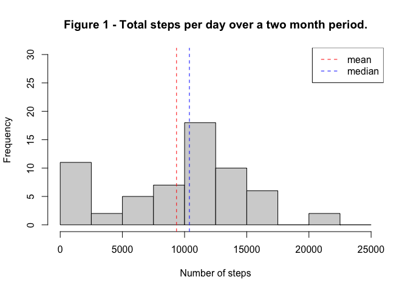

```r
require("dplyr", lib.loc = "http://cran.us.r-project.org")
library(dplyr)
daily <- data %>%
        group_by(as.Date(date)) %>%
        summarise(total = sum(steps, na.rm = TRUE))
daily <- daily[-1,]
daily_mean <- mean(daily$total)
daily_median <- median(daily$total)
uncorrected <- hist(daily$total,
     xlab = "Number of steps",
     ylim = c(0,30),
     main = "Figure 1 - Total steps per day over a two month period.",
     breaks = c(seq(from = 0, to = 25000, by = 2500)),
     xlim = c(0,25000))
abline(v = daily_mean, col = "red", lty =2)
abline(v = daily_median, col = "blue", lty =2)
legend("topright",
       col = c("red","blue"),
       lty = 2,
       legend = c("mean", "median"))
```

The histogram for the activity levels during this period can be seen in **Figure 1.**The mean number of steps taken per day between the 1st October 2012 and the 30th of November 2012 was **9,354** and the median was **10,389**.

## What is the average daily activity pattern?

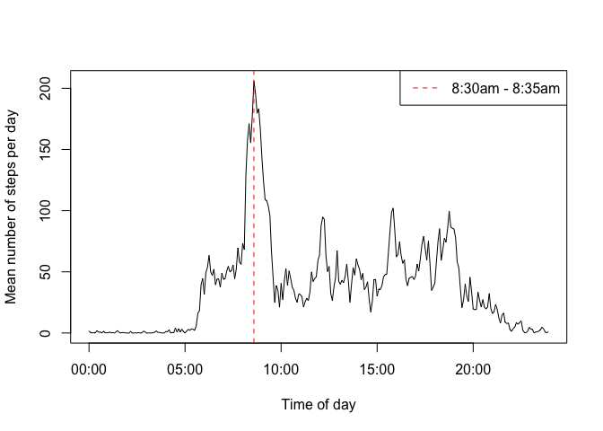

```r
daily_interval <- data %>%
        arrange(interval) %>%
        group_by(interval) %>%
        summarise(mean_steps = mean(steps, na.rm = TRUE))
daily_interval$hours <- daily_interval$interval %/% 100
daily_interval$minutes <- daily_interval$interval %% 100
daily_interval$minutes <- sapply(daily_interval$minutes,
                                function(x) {
                                        if(x < 10) {
                                                paste("0",x, sep = "")
                                        } else {return(x)}

                                 })
daily_interval$hours <- sapply(daily_interval$hours,
                                function(x) {
                                        if(x < 10) {
                                                paste("0",x, sep = "")
                                        } else {return(x)}

                                 })
daily_interval$time_of_day <- with(daily_interval,
                                   paste(hours,":",minutes, sep = ""))
daily_interval$time_of_day <- as.POSIXct(daily_interval$time_of_day,
                                         format = "%H:%M")
with(data=daily_interval,
     plot(time_of_day,
          mean_steps, type = "l",
          xlab = "Time of day", ylab = "Mean number of steps per day"),             xlim = c(0,24:00))
highest_activity <- max(daily_interval$mean_steps, na.rm = TRUE)
highest_entry <- daily_interval[daily_interval$mean_steps == highest_activity,]
abline(v = highest_entry$time_of_day, col = "red", lty = 2)
legend("topright",
       lty = 2,
       col = "red",
       legend = "8:30am - 8:35am")
```

The interval of the day that sees the highest mean number of steps is between **830am** and **835am** .